# Simulating Many Scenarios

Manuel D. Rossetti, PhD P.E.

## Learning Objectives

- To explain how a KSL model is *instrumented* so its inputs can be changed generically for analysis
- To expose model inputs as controls using the `@set:KSLControl` annotation and access them with `model.controls()`
- To change random-variable parameters generically with the `RVParameterSetter` class
- To generalize model construction using the `ModelBuilderIfc` interface
- To define and execute many configurations with `Scenario`, `ScenarioRunner`, and `ConcurrentScenarioRunner`
- To screen for the best configuration using the `MultipleComparisonAnalyzer` (MCB)

## Two Questions, One Prerequisite

- Earlier chapters compared a *few* system configurations. This chapter scales that up. It does two things:
  - simulate *many* configurations — **scenarios** (this deck)
  - systematically explore the design space — **design of experiments** (next deck)
- Both beg the same question: *how do we specify a configuration to analyze?*
- A simulation model has many parameters; each setting is a different configuration, and all settings form the *design space*.
- **The one prerequisite:** we must *instrument* the model so its parameters of interest can be controlled from outside the model code.

## Roadmap: Instrument, Run, Compare

- **Instrument the model** — make inputs settable by name
  - controls via `@set:KSLControl` and `model.controls()`
  - random-variable parameters via `RVParameterSetter`
  - a unified *flat key* naming scheme for both
- **Generalize construction** — `ModelBuilderIfc`, a repeatable model recipe
- **Run many configurations** — `Scenario` with `ScenarioRunner` (sequential) or `ConcurrentScenarioRunner` (parallel)
- **Compare** — `MultipleComparisonAnalyzer` (MCB)
- Running example throughout: the **`PalletWorkCenter`** model, varying the number of workers

## Controls: The `@set:KSLControl` Annotation

- A **control** exposes a model-element property so it can be set generically before a run (via reflection, in the `ksl.controls` package)
- Annotate the property’s *setter* with `@set:KSLControl`; supply a `controlType` from the `ControlType` enum plus optional bounds
- Numeric types (Double, Int, Long, Short, Byte, Float) are all handled as a Double and converted on assignment; Boolean maps 1.0/0.0
- Here `numWorkers` on `PalletWorkCenter` is exposed as an integer control with a lower bound of 1

```kotlin
@set:KSLControl(
    controlType = ControlType.INTEGER,
    lowerBound = 1.0
)
var numWorkers = numWorkers
    set(value) {
        require(value >= 1) { "The number of workers must be >= 1" }
        require(!model.isRunning) { "Cannot change the number of workers while the model is running!" }
        field = value
    }
```

## Accessing Controls and Their Keys

- `Model.controls()` returns all controls for every element in the model
- Each control has a unique **key**: the element’s name + the property name, e.g. `PWC.numWorkers`
- Look up a control by key and assign its `value`; the underlying property updates
- KSL elements may already be annotated (e.g. every `Variable` has an `initialValue` control)

```kotlin
val model = Model("Pallet Model MCB")
val palletWorkCenter = PalletWorkCenter(model, name = "PWC")

val controls = model.controls()
for (controlKey in controls.controlKeys()) {
    println(controlKey)
}
// look up a control by its unique key, then set it
val control = controls.control("PWC.numWorkers")!!
control.value = 3.0   // numWorkers is now 3
```

```
PWC.numWorkers
NumBusyWorkers.initialValue
Num Processed.initialCounterLimit
P{total time > 480 minutes}.initialValue
```

## Changing Random-Variable Parameters

- Random variables are *immutable*, and parameter counts vary by type — so the KSL provides a generic protocol: `RVParameterSetter` (`ksl.rvariable.parameters`)
- `rvParameters` maps each RV’s name to an `RVParameters` object holding its Double/Int/DoubleArray parameters
- Change a value with `changeDoubleParameter(name, value)` — but the change is staged, not yet applied
- Call `applyParameterChanges(model)` to push the change into the model

```kotlin
val setter = RVParameterSetter(model)
val map = setter.rvParameters
for ((key, value) in map) {
    println("$key -> $value")
}
// change the mode of the triangular processing-time RV
val rv = map["ProcessingTimeRV"]!!
rv.changeDoubleParameter("mode", 14.0)
setter.applyParameterChanges(model)   // <-- required to take effect
```

## One Flat Key Space for Controls and Parameters

- `RVParameterSetter` also exposes a **flattened** view via `flatParametersAsDoubles`
- Each key = RV name + `.` + parameter name, so every parameter gets a unique string key
- This matches the control-key format (`PWC.numWorkers`) — one uniform naming scheme for *both* controls and RV parameters
- That shared scheme is exactly what scenarios use to specify inputs

```kotlin
val flatMap = setter.flatParametersAsDoubles
for ((key, value) in flatMap) {
    println("$key -> $value")
}
```

```
ProcessingTimeRV.min       -> 8.0
ProcessingTimeRV.mode      -> 14.0
ProcessingTimeRV.max       -> 15.0
TransportTimeRV.mean       -> 5.0
NumPalletsRV.probOfSuccess -> 0.8
NumPalletsRV.numTrials     -> 100.0
```

## Generalizing Construction: `ModelBuilderIfc`

- To reuse a model (in experiments, apps, or concurrent runs), wrap the “create model → add elements → configure” recipe in a `ModelBuilderIfc`
- Its `build()` returns a fresh, fully-configured `Model`; calling it twice yields two *completely independent* models
- Keep `build()` simple and set run defaults (replications, run length) inside it

```kotlin
interface ModelBuilderIfc {
    fun build(
        modelConfiguration: Map<String, String>? = null,
        experimentRunParameters: ExperimentRunParametersIfc? = null
    ): Model
}

object BuildPalletWorkCenter : ModelBuilderIfc {
    override fun build(
        modelConfiguration: Map<String, String>?,
        experimentRunParameters: ExperimentRunParametersIfc?
    ): Model {
        val model = Model("Pallet Model")
        PalletWorkCenter(model, name = "PWC")
        model.numberOfReplications = 30
        return model
    }
}
```

## Defining and Running Scenarios: `ScenarioRunner`

- A `Scenario` = a model (or model builder) + an **inputs map** of flat key → value + a unique **name**
- The inputs map uses the same flat keys we just saw — controls and RV parameters together
- `ScenarioRunner` batch-runs a list of scenarios and captures every result in a `KSLDatabase` (`kslDb`)
- The scenario name becomes the experiment name, so keep names unique

```kotlin
fun buildScenarios(): List<Scenario> {
    val model = Model("Pallet Model")
    PalletWorkCenter(model, name = "PWC")
    model.numberOfReplications = 30
    val s1 = Scenario(model = model, name = "One Worker",
        inputs = mapOf("PWC.numWorkers" to 1.0))
    val s2 = Scenario(model = model, name = "Two Worker",
        inputs = mapOf("PWC.numWorkers" to 2.0))
    val s3 = Scenario(model = model, name = "Three Worker",
        inputs = mapOf("PWC.numWorkers" to 3.0))
    return listOf(s1, s2, s3)
}

val runner = ScenarioRunner("Pallet Comparison", buildScenarios())
runner.simulate()
```

## Running Scenarios Concurrently: `ConcurrentScenarioRunner`

- `ScenarioRunner` runs scenarios one at a time; `ConcurrentScenarioRunner` runs them in parallel, cutting wall-clock time by roughly the number of cores
- Same constructor (name, scenario list, database); `simulate()` is a `suspend` function, so wrap `main` in `runBlocking`
- **Requires builder-based scenarios**, never a shared `Model`: each scenario calls `build()` for its own private model — a shared model would race. Submitting a shared-model scenario throws immediately.
- By default all scenarios start from the same streams → **common random numbers (CRN)**, exactly what we want when comparing alternatives; call `useIndependentRandomStreams()` to opt out

```kotlin
fun main() = runBlocking {
    val s1 = Scenario(BuildPalletWorkCenter, "One Worker", mapOf("PWC.numWorkers" to 1.0))
    val s2 = Scenario(BuildPalletWorkCenter, "Two Worker", mapOf("PWC.numWorkers" to 2.0))
    val s3 = Scenario(BuildPalletWorkCenter, "Three Worker", mapOf("PWC.numWorkers" to 3.0))

    val runner = ConcurrentScenarioRunner("Pallet Comparison", listOf(s1, s2, s3))
    runner.simulate()
    runner.print()
}
```

## Comparing Scenario Results: MCB

- Both runners store all results in a `KSLDatabase` (`runner.kslDb`), organized by scenario (see output structure)
- Build a `MultipleComparisonAnalyzer` (MCB) directly from the database to screen for the best configuration — same API for either runner
- `multipleComparisonAnalyzerFor()` takes the experiment names and the response name to compare

```kotlin
val responseName = PalletWorkCenter(Model()).totalProcessingTime.name
val mca = runner.kslDb.multipleComparisonAnalyzerFor(
    expNames = runner.scenarioList.map { it.name },
    responseName = responseName
)
println(mca)
```

- **Next deck:** hand-listing scenarios works for a handful of configurations — when factors and levels multiply, we turn to systematic *experimental design*.

## Where the Results Are Stored

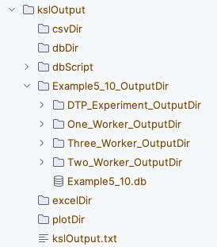

Scenario output directories and the captured KSL database

⌂ Index